# Visualização de Dados

Propósitos de Visualização dados: gapminder

Nathália Demetrio

```r
source("https://raw.githubusercontent.com/traffordDataLab/assets/601e80334e0d78dfe913685561196b8b6fc278a7/theme/ggplot2/theme_lab.R")

theme_nath <- function () {
  theme_grey(base_size = 11.5, base_family = "Roboto") %+replace%
    theme(
      # add padding to the plot
      plot.margin = unit(rep(0.5, 4), "cm"),
      # remove the plot background and border
      plot.background = element_blank(),
      panel.background = element_blank(),
      panel.border = element_blank(),
      # make the legend and strip background transparent
      legend.background = element_rect(fill = "transparent", colour = NA),
      legend.key = element_rect(fill = "transparent", colour = NA),
      strip.background = element_rect(fill = "transparent", colour = NA),
      # add light, dotted major grid lines only
      panel.grid.major = element_line(linetype = "dotted", colour = "#757575", size = 0.3),
      panel.grid.minor = element_blank(),
      # remove the axis tick marks and hide axis lines
      axis.ticks = element_blank(),
      axis.line = element_line(color = "#FFFFFF", size = 0.3),
      # modify the bottom margins of the title and subtitle
      plot.title = element_text(size = 18, colour = "#757575", hjust = 0, margin = margin(b = 4)),
      plot.subtitle = element_text(size = 12, colour = "#757575", hjust = 0, margin = margin(b = 10)),
      # add padding to the caption
      plot.caption = element_text(size = 10, colour = "#757575", hjust = 1, margin = margin(t = 15)),
      # change to Open Sans for axes titles, tick labels, legend title and legend key, and strip text
      axis.title = element_text(family = "Open Sans", size = 11, colour = "#757575", face = "plain", hjust = 1),
      axis.text = element_text(family = "Open Sans", size = 10, colour = "#757575", face = "plain"),
      legend.title = element_text(size = 12, colour = "#757575"),
      legend.text = element_text(size = 10, colour = "#757575"),
      strip.text = element_text(family = "Open Sans", size = 12, colour = "#757575", face = "plain")
    )
}

#lista de cores da paleta
#Set2 = c("#66C2A5", "#FC8D62", "#8DA0CB", "#E78AC3", "#A6D854", "#FFD92F", "#E5C494", "#B3B3B3")
```

```r
library(tidyverse)
library(patchwork)
```

# Introdução

Este arquivo concentra as visualizações relacionadas aos dados do gapminder.

# Dados

Serão utilizados dados da iniciativa gapminder, disponibilizada em gapminder::gapminder e dslabs::gapminder, tendo que neste último algumas informações a mais são disponibilizadas.

## dslabs

Esta base possui vários anos a mais que a base original, além da informação de `region`, mais países, e as features `infant_mortality` e `fertility`. Contudo os valores das variáveis: population, gdp e life_expectancy, infos que também constam na base orginal do gapminder, possuem valores razoavelmente distintos (da base original, e um pouco distoantes dentro do próprio histórico).  
No mais, após o merge com as bases originais, o `infant_mortality` particularmente apresenta muitos NAs, bem como o `gdp`.

```r
dslabs <- dslabs::gapminder %>%
  #anos da base gapminder::gapminder
  filter(year %in% c(1952, 1957, 1962, 1967, 1972, 1977,
                     1982, 1987, 1992, 1997, 2002, 2007)) %>%
  select(-life_expectancy, -population, -gdp) %>%
  glimpse()
```

```
## Rows: 1,850
## Columns: 6
## $ country          <fct> "Albania", "Algeria", "Angola", "Antigua and Barbuda"…
## $ year             <int> 1962, 1962, 1962, 1962, 1962, 1962, 1962, 1962, 1962,…
## $ infant_mortality <dbl> 106.50, 148.20, NA, NA, 59.59, NA, NA, 19.50, 32.90, …
## $ fertility        <dbl> 5.96, 7.65, 7.39, 4.34, 3.09, 4.44, 4.47, 3.43, 2.80,…
## $ continent        <fct> Europe, Africa, Africa, Americas, Americas, Asia, Ame…
## $ region           <fct> Southern Europe, Northern Africa, Middle Africa, Cari…
```

## gapminder

A base gapminder tratada tem um total de 142 países para cada um dos anos, com 12 anos distintos, entre 1952 e 2007 .

```r
gapminder <- gapminder::gapminder %>%
  left_join(gapminder::country_codes) %>%
  left_join(dslabs) %>%
  mutate(region = case_when(
        country == "Afghanistan" ~ "Central Asia",
        country == "Korea, Dem. Rep." ~ "Eastern Asia",
        country == "Korea, Rep." ~ "Eastern Asia",
        country == "Myanmar" ~ "Southeast Asia",
        country == "Reunion" ~ "Eastern Africa",
        country == "Sao Tome and Principe" ~ "Central Africa",
        country == "Somalia" ~ "Eastern Africa",
        country == "Taiwan" ~ "Eastern Asia",
        country == "Turkey" ~ "Western Asia",
        country == "Yemen, Rep." ~ "Western Asia",
    TRUE ~ region)) %>%
  janitor::clean_names() %>%
  mutate(continent = recode(continent,
                            "Asia" = "Ásia",
                            "Europe" = "Europa",
                            "Africa" = "África",
                            "Americas" = "América",
                            "Oceania" = "Oceania")) %>%
  relocate(region, .after = continent) %>%
  glimpse()
```

```
## Rows: 1,704
## Columns: 11
## $ country          <chr> "Afghanistan", "Afghanistan", "Afghanistan", "Afghani…
## $ continent        <fct> Ásia, Ásia, Ásia, Ásia, Ásia, Ásia, Ásia, Ásia, Ásia,…
## $ region           <chr> "Central Asia", "Central Asia", "Central Asia", "Cent…
## $ year             <int> 1952, 1957, 1962, 1967, 1972, 1977, 1982, 1987, 1992,…
## $ life_exp         <dbl> 28.801, 30.332, 31.997, 34.020, 36.088, 38.438, 39.85…
## $ pop              <int> 8425333, 9240934, 10267083, 11537966, 13079460, 14880…
## $ gdp_percap       <dbl> 779.4453, 820.8530, 853.1007, 836.1971, 739.9811, 786…
## $ iso_alpha        <chr> "AFG", "AFG", "AFG", "AFG", "AFG", "AFG", "AFG", "AFG…
## $ iso_num          <int> 4, 4, 4, 4, 4, 4, 4, 4, 4, 4, 4, 4, 8, 8, 8, 8, 8, 8,…
## $ infant_mortality <dbl> NA, NA, NA, NA, NA, NA, NA, NA, NA, NA, NA, NA, NA, N…
## $ fertility        <dbl> NA, NA, NA, NA, NA, NA, NA, NA, NA, NA, NA, NA, NA, N…
```

```r
  #código complementar para identificar países sem região atribuída:
  #gapminder %>%   filter(is.na(region)) %>% select(country, continent, region) %>%  unique()
```

## gapminder_full (data frame que será utilizado)

```r
gapminder_full <- gapminder::gapminder_unfiltered %>%
  filter(year %in% c(1952, 1957, 1962, 1967, 1972, 1977, 1982, 1987, 1992, 1997, 2002, 2007)) %>%
  left_join(gapminder::country_codes) %>%
  left_join(dslabs) %>%
  mutate(region = case_when(
      country == "Afghanistan" ~ "Central Asia",
      country == "Korea, Dem. Rep." ~ "Eastern Asia",
      country == "Korea, Rep." ~ "Eastern Asia",
      country == "Myanmar" ~ "Southeast Asia",
      country == "Reunion" ~ "Eastern Africa",
      country == "Sao Tome and Principe" ~ "Central Africa",
      country == "Somalia" ~ "Eastern Africa",
      country == "Taiwan" ~ "Eastern Asia",
      country == "Turkey" ~ "Western Asia",
      country == "Yemen, Rep." ~ "Western Asia",
  TRUE ~ region)) %>%
  mutate(region = case_when(
      country == "Cyprus" ~ "Western Asia",
      country == "French Guiana" ~ "South America",
      country == "Guadeloupe" ~ "Caribbean",
      country == "Martinique" ~ "Caribbean",
      country == "Netherlands Antilles" ~ "South America",
  TRUE ~ region)) %>%
  janitor::clean_names() %>%
  mutate(continent = recode(continent,
                                 "Asia" = "Ásia",
                                 "Europe" = "Europa",
                                 "Africa" = "África",
                                 "Americas" = "América",
                                 "Oceania" = "Oceania")) %>%
  relocate(region, .after = continent) %>%
  glimpse()
```

```
## Rows: 2,013
## Columns: 11
## $ country          <chr> "Afghanistan", "Afghanistan", "Afghanistan", "Afghani…
## $ continent        <fct> Ásia, Ásia, Ásia, Ásia, Ásia, Ásia, Ásia, Ásia, Ásia,…
## $ region           <chr> "Central Asia", "Central Asia", "Central Asia", "Cent…
## $ year             <int> 1952, 1957, 1962, 1967, 1972, 1977, 1982, 1987, 1992,…
## $ life_exp         <dbl> 28.801, 30.332, 31.997, 34.020, 36.088, 38.438, 39.85…
## $ pop              <int> 8425333, 9240934, 10267083, 11537966, 13079460, 14880…
## $ gdp_percap       <dbl> 779.4453, 820.8530, 853.1007, 836.1971, 739.9811, 786…
## $ iso_alpha        <chr> "AFG", "AFG", "AFG", "AFG", "AFG", "AFG", "AFG", "AFG…
## $ iso_num          <int> 4, 4, 4, 4, 4, 4, 4, 4, 4, 4, 4, 4, 8, 8, 8, 8, 8, 8,…
## $ infant_mortality <dbl> NA, NA, NA, NA, NA, NA, NA, NA, NA, NA, NA, NA, NA, N…
## $ fertility        <dbl> NA, NA, NA, NA, NA, NA, NA, NA, NA, NA, NA, NA, NA, N…
```

### view

```r
gapminder_full %>% DT::datatable()
```

|  | country | continent | region | year | life_exp | pop | gdp_percap | iso_alpha | iso_num | infant_mortality | fertility |
| --- | --- | --- | --- | --- | --- | --- | --- | --- | --- | --- | --- |
| 1 | Afghanistan | Ásia | Central Asia | 1952 | 28.801 | 8425333 | 779.4453145 | AFG | 4 |  |  |
| 2 | Afghanistan | Ásia | Central Asia | 1957 | 30.332 | 9240934 | 820.8530296 | AFG | 4 |  |  |
| 3 | Afghanistan | Ásia | Central Asia | 1962 | 31.997 | 10267083 | 853.10071 | AFG | 4 |  |  |
| 4 | Afghanistan | Ásia | Central Asia | 1967 | 34.02 | 11537966 | 836.1971382 | AFG | 4 |  |  |
| 5 | Afghanistan | Ásia | Central Asia | 1972 | 36.088 | 13079460 | 739.9811058 | AFG | 4 |  |  |
| 6 | Afghanistan | Ásia | Central Asia | 1977 | 38.438 | 14880372 | 786.11336 | AFG | 4 |  |  |
| 7 | Afghanistan | Ásia | Central Asia | 1982 | 39.854 | 12881816 | 978.0114388 | AFG | 4 |  |  |
| 8 | Afghanistan | Ásia | Central Asia | 1987 | 40.822 | 13867957 | 852.3959448 | AFG | 4 |  |  |
| 9 | Afghanistan | Ásia | Central Asia | 1992 | 41.674 | 16317921 | 649.3413952 | AFG | 4 |  |  |
| 10 | Afghanistan | Ásia | Central Asia | 1997 | 41.763 | 22227415 | 635.341351 | AFG | 4 |  |  |

[output cut: 2003 more lines]

# Magnitude

Este capítulo se baseia nas análises feitas pelo @traffordDataLab

## Qtd países por continente

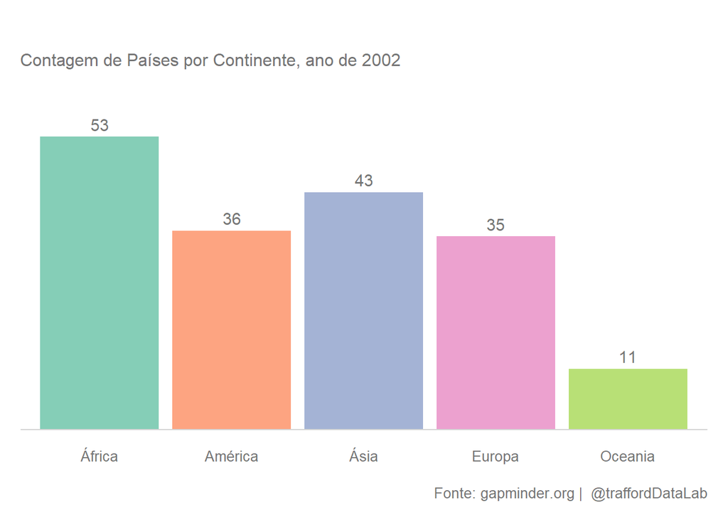

```r
gapminder_full %>%
  filter(continent != "FSU") %>%
  filter(year == "2002") %>%
  group_by(continent) %>%
  count() %>%
  ggplot(aes(x = continent, y = n, fill = continent), color = "white")  +
    geom_col(alpha = 0.8) +
    geom_text(aes(label = n), vjust = -0.5, size = 4, colour = "#757575") +
    geom_hline(yintercept=0, color = "lightgrey") +
    scale_fill_brewer(palette = "Set2") +
    labs(title = "",
         subtitle = "Contagem de Países por Continente, ano de 2002",
         caption = "Fonte: gapminder.org |  @traffordDataLab",
         x = NULL,
         y = NULL,
         fill = NULL) +
    theme_nath() +
    scale_y_continuous(limits = c(0, 60)) +
    theme(panel.grid.major.x = element_blank(),
          panel.grid.major.y = element_blank(),
          #panel.grid = element_blank(),
          axis.text.y=element_blank(),
          legend.position = "none")
```

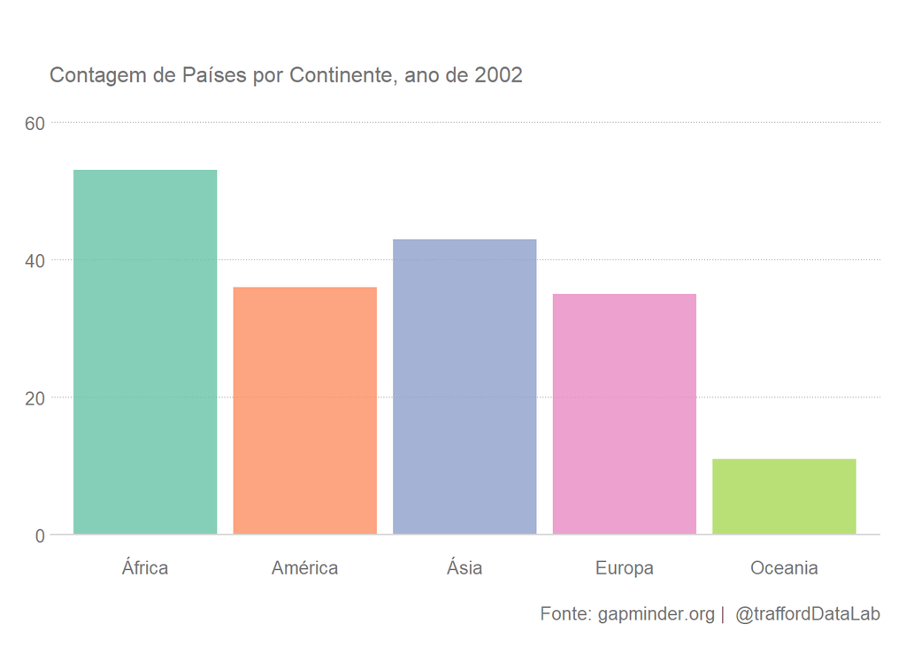

```r
gapminder_full %>%
  filter(continent != "FSU") %>%
  filter(year == "2002") %>%
  group_by(continent) %>%
  count() %>%
  ggplot(aes(x = continent, y = n, fill = continent), color = "white")  +
    geom_col(alpha = 0.8) +
    geom_hline(yintercept=0, color = "lightgrey") +
    scale_fill_brewer(palette = "Set2") +
    labs(title = "",
         subtitle = "Contagem de Países por Continente, ano de 2002",
         caption = "Fonte: gapminder.org |  @traffordDataLab",
         x = NULL,
         y = NULL,
         fill = NULL) +
    theme_nath() +
    scale_y_continuous(limits = c(0, 60)) +
    theme(panel.grid.major.x = element_blank(),
          #panel.grid.major.y = element_blank(),
          #panel.grid = element_blank(),
          #axis.text.y=element_blank(),
          legend.position = "none")
```

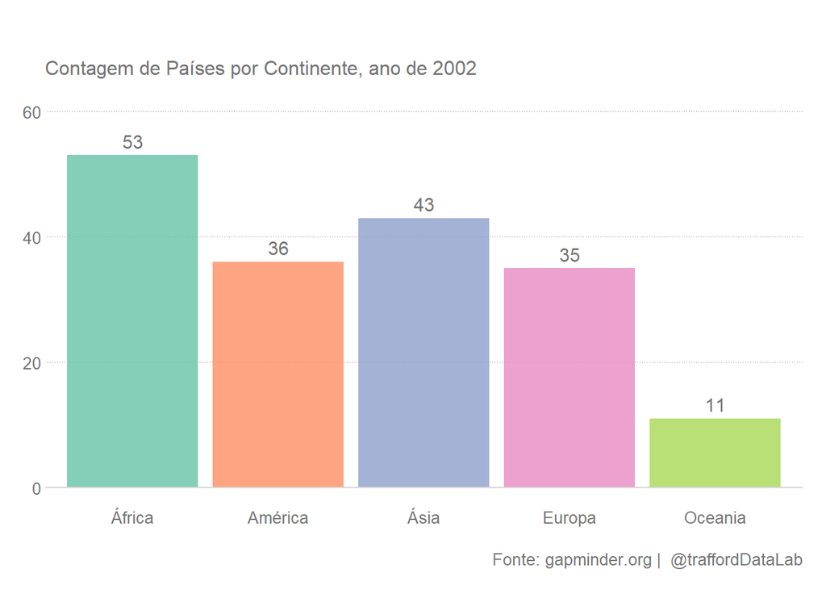

```r
gapminder_full %>%
  filter(continent != "FSU") %>%
  filter(year == "2002") %>%
  group_by(continent) %>%
  count() %>%
  ggplot(aes(x = continent, y = n, fill = continent), color = "white")  +
    geom_col(alpha = 0.8) +
    geom_text(aes(label = n), vjust = -0.5, size = 4, colour = "#757575") +
    geom_hline(yintercept=0, color = "lightgrey") +
    scale_fill_brewer(palette = "Set2") +
    labs(title = "",
         subtitle = "Contagem de Países por Continente, ano de 2002",
         caption = "Fonte: gapminder.org |  @traffordDataLab",
         x = NULL,
         y = NULL,
         fill = NULL) +
    theme_nath() +
    scale_y_continuous(limits = c(0, 60)) +
    theme(panel.grid.major.x = element_blank(),
          #panel.grid.major.y = element_blank(),
          #panel.grid = element_blank(),
          #axis.text.y=element_blank(),
          legend.position = "none")
```

## Life_exp

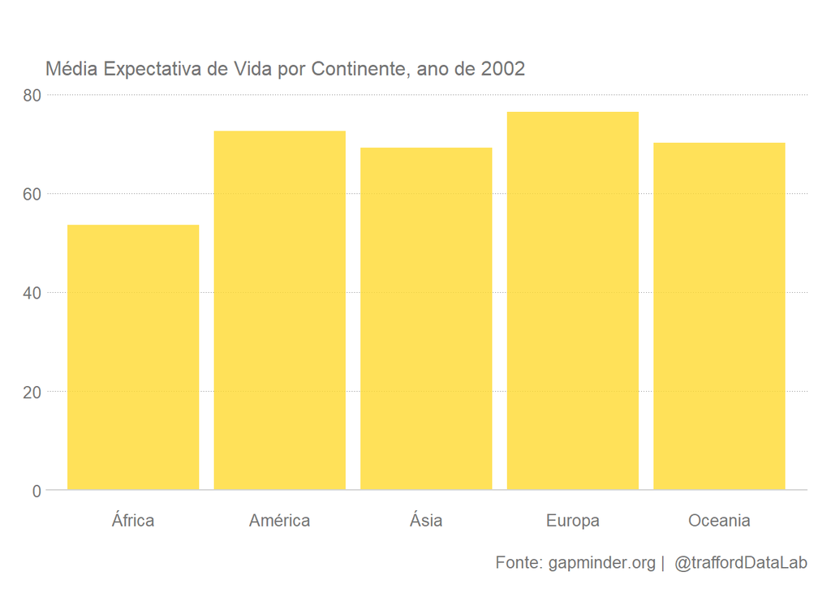

```r
gapminder_full %>%
  filter(continent != "FSU") %>%
  filter(year == "2002") %>%
  group_by(continent) %>%
  summarise(life_exp = mean(life_exp)) %>%
  ggplot(aes(x = continent, y = life_exp, fill = continent))  +
  geom_col(fill = "#FFD92F", alpha = 0.8) +
  geom_hline(yintercept=0, color = "lightgrey") +
  labs(title = "",
       subtitle = "Média Expectativa de Vida por Continente, ano de 2002",
       caption = "Fonte: gapminder.org |  @traffordDataLab",
       x = NULL,
       y = NULL,
       fill = NULL) +
  theme_nath() +
  theme(panel.grid.major.x = element_blank(),
        legend.position = "none")
```

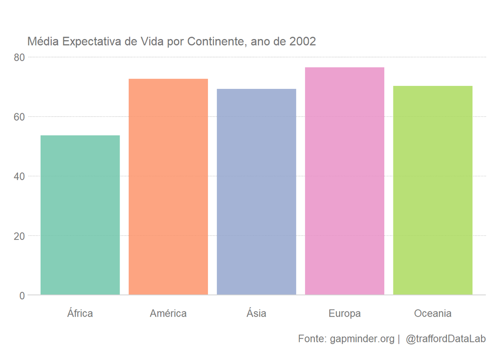

```r
gapminder_full %>%
  filter(continent != "FSU") %>%
  filter(year == "2002") %>%
  group_by(continent) %>%
  summarise(life_exp = mean(life_exp)) %>%
  ggplot(aes(x = continent, y = life_exp, fill = continent))  +
  geom_col(alpha = 0.8) +
  geom_hline(yintercept=0, color = "lightgrey") +
  scale_fill_brewer(palette = "Set2") +
  labs(title = "",
       subtitle = "Média Expectativa de Vida por Continente, ano de 2002",
       caption = "Fonte: gapminder.org |  @traffordDataLab",
       x = NULL,
       y = NULL,
       fill = NULL) +
  theme_nath() +
  theme(panel.grid.major.x = element_blank(),
        legend.position = "none")
```

# Comparação

## absoluta

### agrupado

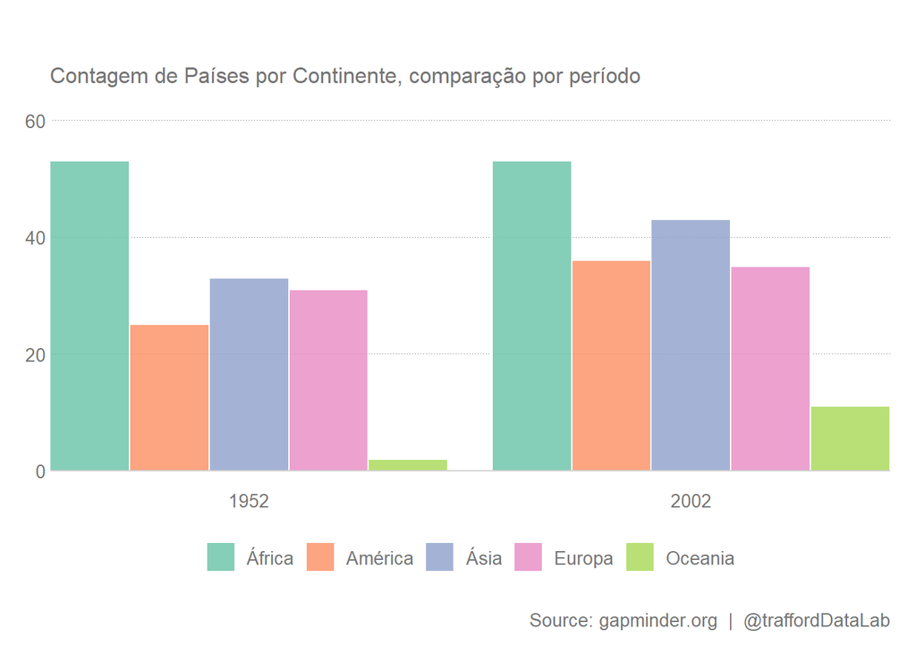

```r
gapminder_full %>%
  filter(continent != "FSU") %>%
  filter(year %in% c(1952,  2002)) %>%
  group_by(year, continent) %>%
  count() %>%
  ggplot(aes(x = year, y = n, group = continent, fill = continent)) +
  geom_col(position = "dodge", colour = "white", size = 0.2, alpha = 0.8) +
  geom_hline(yintercept=0, color = "lightgrey") +
  scale_x_continuous(breaks = c(1952, 2002), expand = c(0, 0)) +
  scale_y_continuous(labels = scales::comma, expand = c(0, 0)) +
  scale_fill_brewer(palette = "Set2") +
  labs(title = "",
       subtitle = "Contagem de Países por Continente, comparação por período",
       caption = "Source: gapminder.org  |  @traffordDataLab",
       x = NULL,
       y = NULL,
       fill = NULL) +
  theme_nath() +
  scale_y_continuous(limits = c(0, 60)) +
  theme(panel.grid.major.x = element_blank(),
        legend.position = "bottom")
```

```r
gapminder_full
```

```
## # A tibble: 2,013 × 11
##    country   continent region  year life_exp    pop gdp_percap iso_alpha iso_num
##    <chr>     <fct>     <chr>  <int>    <dbl>  <int>      <dbl> <chr>       <int>
##  1 Afghanis… Ásia      Centr…  1952     28.8 8.43e6       779. AFG             4
##  2 Afghanis… Ásia      Centr…  1957     30.3 9.24e6       821. AFG             4
##  3 Afghanis… Ásia      Centr…  1962     32.0 1.03e7       853. AFG             4
##  4 Afghanis… Ásia      Centr…  1967     34.0 1.15e7       836. AFG             4
##  5 Afghanis… Ásia      Centr…  1972     36.1 1.31e7       740. AFG             4
##  6 Afghanis… Ásia      Centr…  1977     38.4 1.49e7       786. AFG             4
##  7 Afghanis… Ásia      Centr…  1982     39.9 1.29e7       978. AFG             4
##  8 Afghanis… Ásia      Centr…  1987     40.8 1.39e7       852. AFG             4
##  9 Afghanis… Ásia      Centr…  1992     41.7 1.63e7       649. AFG             4
## 10 Afghanis… Ásia      Centr…  1997     41.8 2.22e7       635. AFG             4
## # ℹ 2,003 more rows
## # ℹ 2 more variables: infant_mortality <dbl>, fertility <dbl>
```

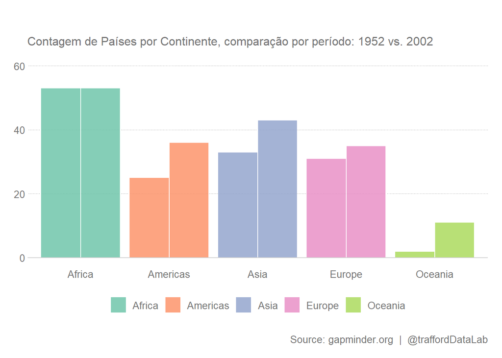

```r
gapminder::gapminder_unfiltered %>%
  filter(continent != "FSU") %>%
  filter(year %in% c(1952,  2002)) %>%
  group_by(year, continent) %>%
  count() %>%
  mutate(year = as.character(year)) %>%
  ggplot(aes(x = continent, y = n, group = year, fill = continent)) +
  geom_col(position = "dodge", colour = "white", size = 0.2, alpha = 0.8) +
  geom_hline(yintercept=0, color = "lightgrey") +
  scale_fill_brewer(palette = "Set2") +
  labs(title = "",
       subtitle = "Contagem de Países por Continente, comparação por período: 1952 vs. 2002",
       caption = "Source: gapminder.org  |  @traffordDataLab",
       x = NULL, y = NULL, fill = NULL) +
  theme_nath() +
  scale_y_continuous(limits = c(0, 60)) +
  theme(panel.grid.major.x = element_blank(),
        legend.position = "bottom")
```

```r
gapminder_full
```

```
## # A tibble: 2,013 × 11
##    country   continent region  year life_exp    pop gdp_percap iso_alpha iso_num
##    <chr>     <fct>     <chr>  <int>    <dbl>  <int>      <dbl> <chr>       <int>
##  1 Afghanis… Ásia      Centr…  1952     28.8 8.43e6       779. AFG             4
##  2 Afghanis… Ásia      Centr…  1957     30.3 9.24e6       821. AFG             4
##  3 Afghanis… Ásia      Centr…  1962     32.0 1.03e7       853. AFG             4
##  4 Afghanis… Ásia      Centr…  1967     34.0 1.15e7       836. AFG             4
##  5 Afghanis… Ásia      Centr…  1972     36.1 1.31e7       740. AFG             4
##  6 Afghanis… Ásia      Centr…  1977     38.4 1.49e7       786. AFG             4
##  7 Afghanis… Ásia      Centr…  1982     39.9 1.29e7       978. AFG             4
##  8 Afghanis… Ásia      Centr…  1987     40.8 1.39e7       852. AFG             4
##  9 Afghanis… Ásia      Centr…  1992     41.7 1.63e7       649. AFG             4
## 10 Afghanis… Ásia      Centr…  1997     41.8 2.22e7       635. AFG             4
## # ℹ 2,003 more rows
## # ℹ 2 more variables: infant_mortality <dbl>, fertility <dbl>
```

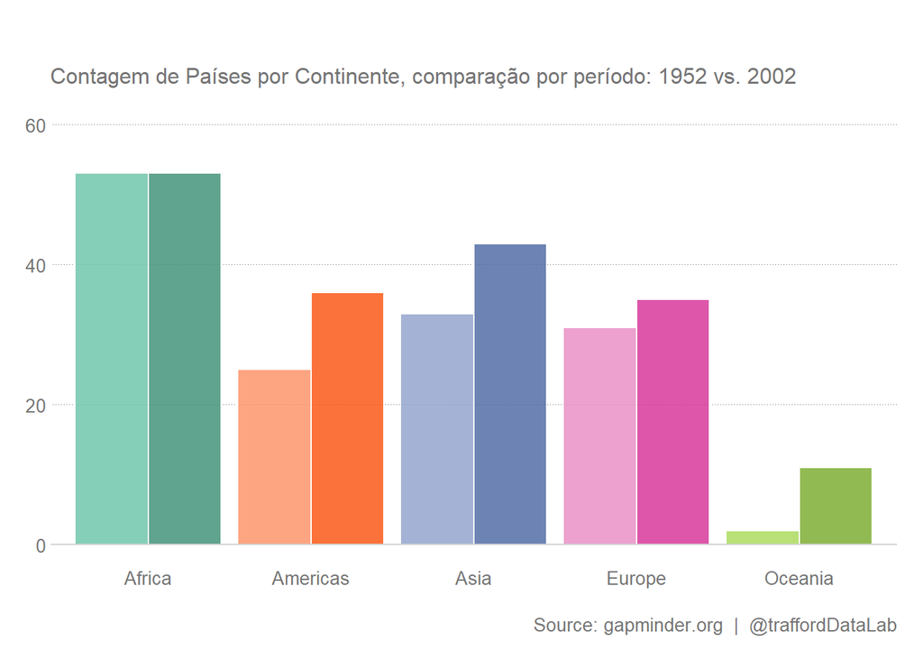

```r
gapminder::gapminder_unfiltered %>%
  filter(continent != "FSU") %>%
  filter(year %in% c(1952,  2002)) %>%
  group_by(year, continent) %>%
  count() %>%
  mutate(year = as.character(year)) %>%
  ggplot(aes(x = continent, y = n, group = year,
             fill = interaction(year, continent))) +
  geom_col(position = "dodge", colour = "white", size = 0.2, alpha = 0.8) +
  geom_hline(yintercept=0, color = "lightgrey") +
  scale_fill_manual(values = c("#66C2A5", "#388C72", "#FC8D62", "#FA4F0A",
                                  "#8DA0CB","#4964A1", "#E78AC3","#D42C94",
                                  "#A6D854", "#77A927")) +
  labs(title = "",
       subtitle = "Contagem de Países por Continente, comparação por período: 1952 vs. 2002",
       caption = "Source: gapminder.org  |  @traffordDataLab",
       x = NULL, y = NULL, fill = NULL) +
  theme_nath() +
  scale_y_continuous(limits = c(0, 60)) +
  theme(panel.grid.major.x = element_blank(),
        legend.position = "none")
```

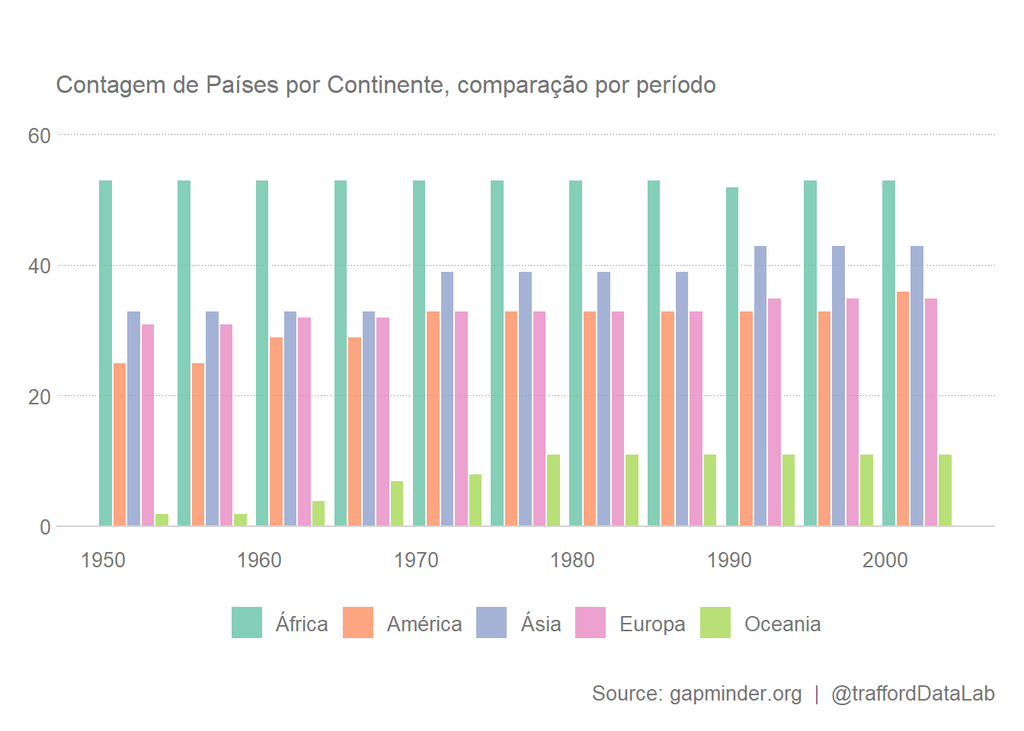

```r
(p1 <- gapminder_full %>%
  filter(continent != "FSU") %>%
  filter(year %in% c(1952, 1957, 1962, 1967, 1972, 1977, 1982, 1987, 1992, 1997, 2002)) %>%
  #filter(year %in% c(1952,  1977, 2002)) %>%
  group_by(year, continent) %>%
  count() %>%
  ggplot(aes(x = year, y = n, group = continent, fill = continent)) +
  geom_col(position = "dodge", colour = "white", size = 0.2, alpha = 0.8) +
  geom_hline(yintercept=0, color = "lightgrey") +
  #scale_x_continuous(breaks = c(1952,  1977, 2002), expand = c(0, 0)) +
  scale_y_continuous(labels = scales::comma, expand = c(0, 0)) +
  scale_fill_brewer(palette = "Set2") +
  labs(title = "",
       subtitle = "Contagem de Países por Continente, comparação por período",
       caption = "Source: gapminder.org  |  @traffordDataLab",
       x = NULL,
       y = NULL,
       fill = NULL) +
  theme_nath() +
  scale_y_continuous(limits = c(0, 60)) +
  theme(panel.grid.major.x = element_blank(),
        legend.position = "bottom"))
```

### agrupado + continent by years

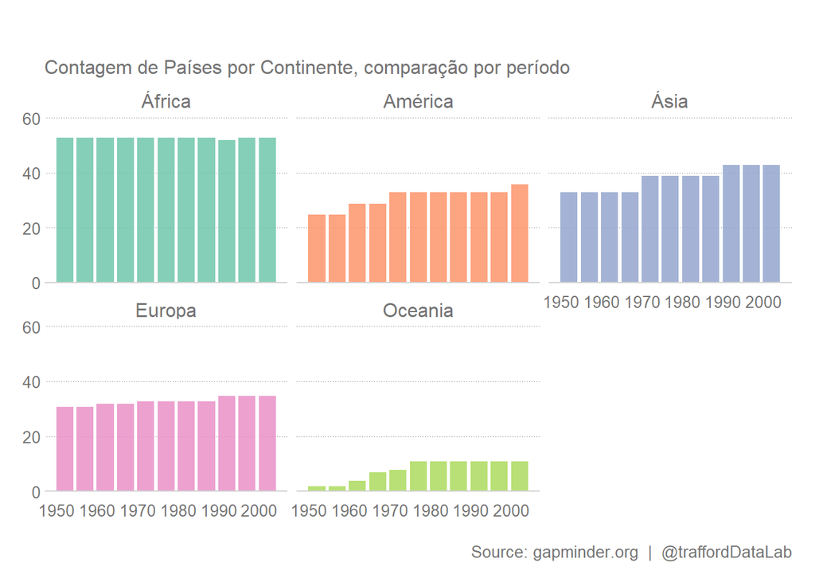

```r
(p0 <- gapminder_full %>%
  filter(continent != "FSU") %>%
  filter(year %in% c(1952, 1957, 1962, 1967, 1972, 1977, 1982, 1987, 1992, 1997, 2002)) %>%
  #filter(year %in% c(1952,  1977, 2002)) %>%
  group_by(year, continent) %>%
  count() %>%
  ggplot(aes(x = year, y = n, group = continent, fill = continent)) +
  geom_col(position = "dodge", colour = "white", size = 0.2, alpha = 0.8) +
   facet_wrap(. ~ continent) +
  geom_hline(yintercept=0, color = "lightgrey") +
  scale_y_continuous(labels = scales::comma, expand = c(0, 0)) +
  scale_fill_brewer(palette = "Set2") +
  labs(title = "",
       subtitle = "Contagem de Países por Continente, comparação por período",
       caption = "Source: gapminder.org  |  @traffordDataLab",
       x = NULL,
       y = NULL,
       fill = NULL) +
  theme_nath() +
  scale_y_continuous(limits = c(0, 60)) +
  theme(panel.grid.major.x = element_blank(),
        legend.position = "none"))
```

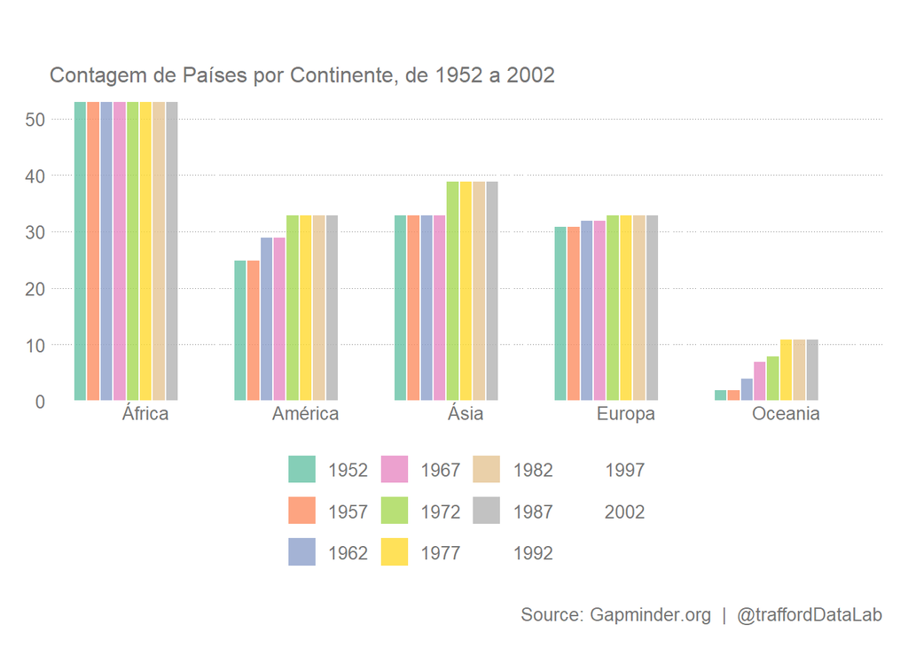

```r
gapminder_full %>%
  filter(continent != "FSU") %>%
  filter(year %in% c(1952, 1957, 1962, 1967, 1972, 1977, 1982, 1987, 1992, 1997, 2002)) %>%
  #filter(year %in% c(1952,  1977, 2002)) %>%
  group_by(year, continent) %>%
  count() %>%
  mutate(year = as_factor(year)) %>%
  ggplot(aes(x = continent, y = n, group = year, fill = year)) +
  geom_col(position = "dodge", colour = "white", size = 0.2, alpha = 0.8) +
  #facet_grid(. ~ year, scales = "free_x") +
  scale_y_continuous(labels = scales::comma, expand = c(0, 0)) +
  scale_fill_brewer(palette = "Set2") +
  labs(title = "",
       subtitle = "Contagem de Países por Continente, de 1952 a 2002",
       caption = "Source: Gapminder.org  |  @traffordDataLab",
       x = NULL,
       y = NULL,
       fill = NULL) +
  theme_nath() +
  theme(panel.grid.major.x = element_blank(),
        legend.position = "bottom")
```

## absoluta e relativa não normalizada

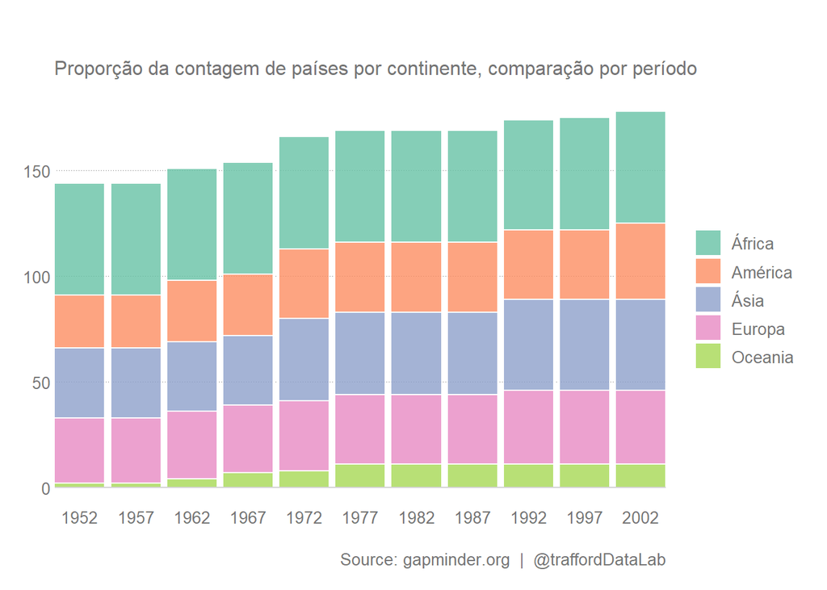

```r
(p2 <- gapminder_full %>%
  filter(continent != "FSU") %>%
  filter(year %in% c(1952, 1957, 1962, 1967, 1972, 1977, 1982, 1987, 1992, 1997, 2002)) %>%
  #filter(year %in% c(1952,  1977, 2002)) %>%
  group_by(year, continent) %>%
  count() %>%
  ggplot(aes(x = year, y = n, fill = continent)) +
  geom_col(colour = "white", size = 0.2, alpha = 0.8) +
  geom_hline(yintercept=0, color = "lightgrey") +
  scale_x_continuous(breaks = c(1952, 1957, 1962, 1967, 1972, 1977, 1982, 1987, 1992, 1997, 2002),
                     expand = c(0, 0)) +
  scale_fill_brewer(palette = "Set2") +
  guides(fill = guide_legend(reverse = F)) +
  labs(title = "",
       subtitle = "Proporção da contagem de países por continente, comparação por período",
       caption = "Source: gapminder.org  |  @traffordDataLab",
       x = NULL,
       y = NULL,
       fill = NULL) +
  theme_nath() +
  theme(panel.grid.major.x = element_blank(),
        legend.position = "right"))
```

## relativa

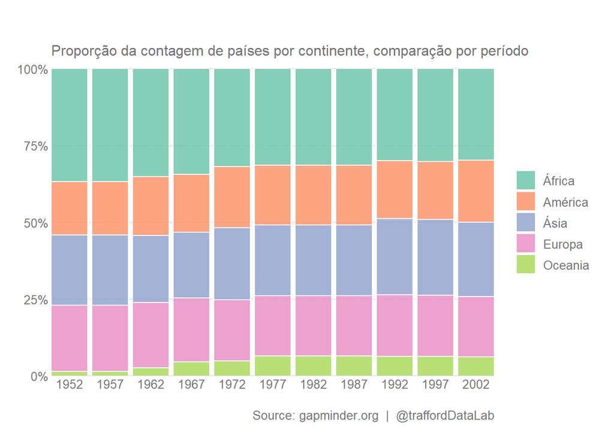

```r
(p3 <- gapminder_full %>%
  filter(continent != "FSU") %>%
  filter(year %in% c(1952, 1957, 1962, 1967, 1972, 1977, 1982, 1987, 1992, 1997, 2002)) %>%
  #filter(year %in% c(1952,  1977, 2002)) %>%
  group_by(year, continent) %>%
  count() %>%
  ggplot(aes(x = year, y = n, fill = continent)) +
  geom_col(position = "fill", colour = "white", size = 0.2, alpha = 0.8) +
  scale_x_continuous(breaks = c(1952, 1957, 1962, 1967, 1972, 1977, 1982, 1987, 1992, 1997, 2002), expand = c(0, 0)) +
  scale_y_continuous(labels = scales::percent, expand = c(0, 0)) +
  scale_fill_brewer(palette = "Set2") +
  guides(fill = guide_legend(reverse = F)) +
  labs(title = "",
       subtitle = "Proporção da contagem de países por continente, comparação por período",
       caption = "Source: gapminder.org  |  @traffordDataLab",
       x = NULL,
       y = NULL,
       fill = NULL) +
  theme_nath() +
 geom_hline(yintercept=0, color = "lightgrey") +
  theme(panel.grid.major.x = element_blank(),
        legend.position = "right"))
```

### clean versions

```r
#patchwork::

(p11 <- p1 +
  theme(legend.position = "none") +
  labs(subtitle = "",
       caption = ""))
```

[output not shown]

```r
(p22 <- p2 +
  theme(legend.position = "none") +
  labs(subtitle = "",
       caption = ""))
```

[output not shown]

```r
(p33 <- p3 +
  theme(legend.position = "none") +
  labs(subtitle = "",
       caption = "") )


(p11 / p22 / p33)
```

[output not shown]

# Relação

## fertility x life_exp (2007)

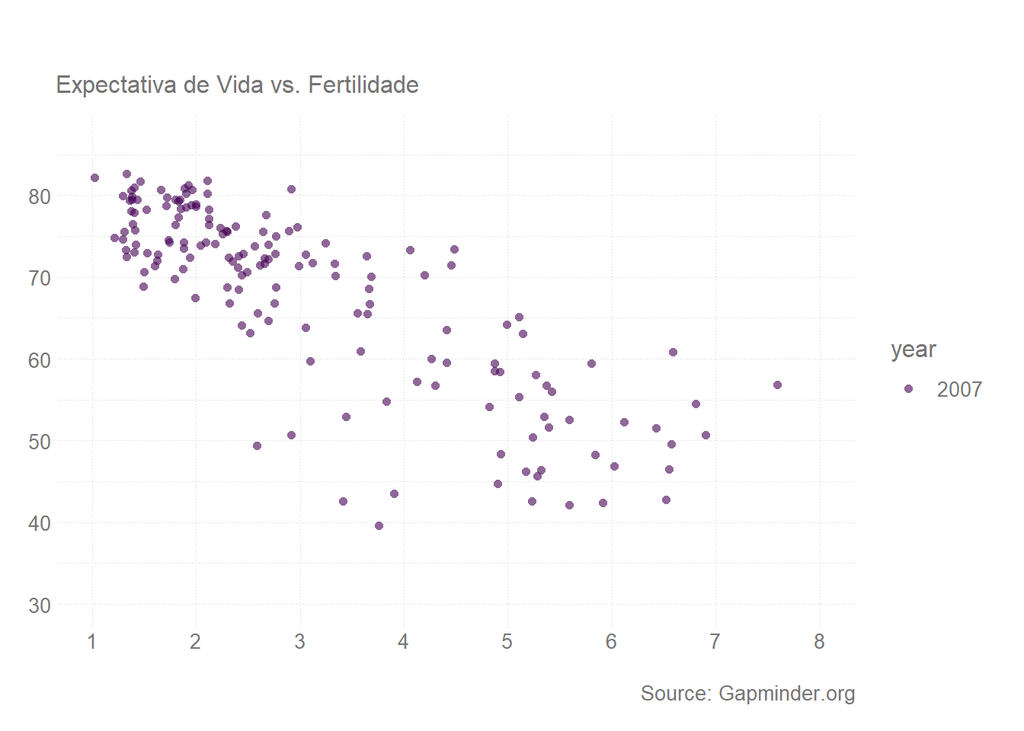

```r
( p <- gapminder_full %>%
  filter(continent != "FSU") %>%
  filter(year %in% c("2007")) %>%
  #filter(continent == "Europa") %>%
  mutate(year = as_factor(year)) %>%
  ggplot(aes(x = fertility, y = life_exp, color = year, label = country))  +
    #scale_y_continuous(labels = scales::comma, expand = c(0, 0)) +
    geom_point(shape=16, size  = 2, stroke = 0, alpha = 0.6) +
    viridis::scale_color_viridis(discrete = T, direction = 1) +
    labs(title = "",
         #subtitle = "Expectativa de Vida vs. Fertilidade, comparação por período",
         subtitle = "Expectativa de Vida vs. Fertilidade",
         caption = "Source: Gapminder.org",
         x = NULL,
         y = NULL,
         fill = NULL) +
    theme_nath() +
    scale_x_continuous(limits = c(1, 8), minor_breaks = seq(1, 8, 1), n.breaks = 8) +
    scale_y_continuous(limits = c(30, 87)) +
    theme(#panel.grid.major.x = element_blank(),
          panel.grid.major = element_line(linetype = "dotted", colour = "lightgrey", size = 0.2),
          panel.grid.minor = element_line(linetype = "dotted", colour = "lightgrey", size = 0.2),
         legend.position = "right"))
```

```r
plotly::ggplotly(p)
```

[interactive chart not shown]

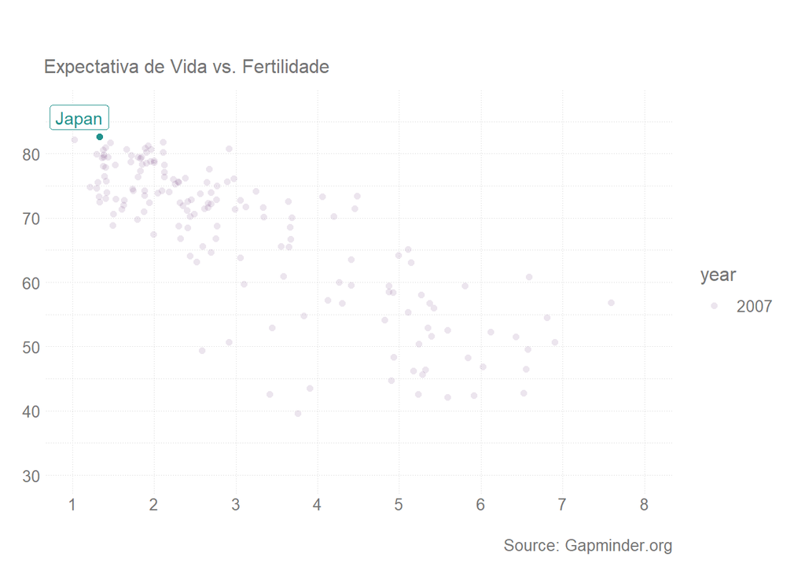

```r
temp <- gapminder_full %>%
  filter(continent != "FSU") %>%
  filter(year %in% c("2007")) %>%
  #filter(continent == "Europa") %>%
  mutate(year = as_factor(year))

(p <- temp %>%
  ggplot(aes(x = fertility, y = life_exp, color = year, label = country))  +
    geom_point(shape=16, size  = 2, stroke = 0, alpha = 0.1) +
    geom_point(data = . %>% filter(country == "Japan"),
               shape=16, size  = 2, stroke = 0, color = "#21918c") +
    ggrepel::geom_label_repel(data = . %>% filter(country == "Japan"),
                          color = "#21918c",
                          max.overlaps = 50,
                          nudge_x = -.3, nudge_y = 3,
                          segment.curvature = 0.5) +
    scale_color_manual(values = c("#440154")) +
    labs(title = "",
         subtitle = "Expectativa de Vida vs. Fertilidade",
         caption = "Source: Gapminder.org",
         x = NULL,
         y = NULL,
         fill = NULL) +
    theme_nath() +
    scale_x_continuous(limits = c(1, 8), minor_breaks = seq(1, 8, 1), n.breaks = 8) +
    scale_y_continuous(limits = c(30, 87)) +
    theme(#panel.grid.major.x = element_blank(),
          panel.grid.major = element_line(linetype = "dotted", colour = "lightgrey", size = 0.2),
          panel.grid.minor = element_line(linetype = "dotted", colour = "lightgrey", size = 0.2),
         legend.position = "right"))
```

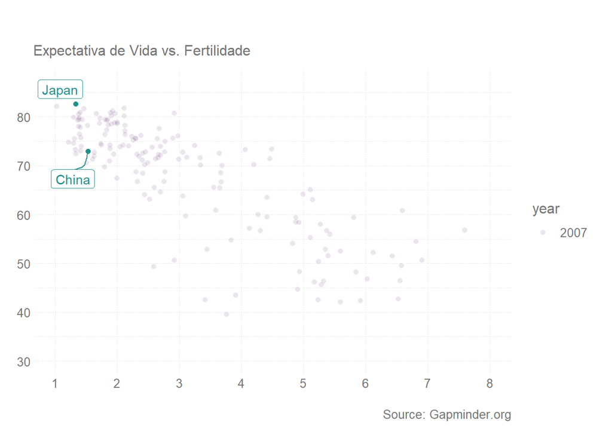

```r
temp <- gapminder_full %>%
  filter(continent != "FSU") %>%
  filter(year %in% c("2007")) %>%
  mutate(year = as_factor(year))

(p <- temp %>%
  ggplot(aes(x = fertility, y = life_exp, color = year, label = country))  +
    geom_point(shape=16, size  = 2, stroke = 0, alpha = 0.1) +
    geom_point(data = . %>% filter(country == "Japan"),
               shape=16, size  = 2, stroke = 0, color = "#21918c") +
    ggrepel::geom_label_repel(data = . %>% filter(country == "Japan"),
                          color = "#21918c",
                          max.overlaps = 50,
                          nudge_x = -.3, nudge_y = 3,
                          segment.curvature = 0.5) +
    geom_point(data = . %>% filter(country == "China"),
               shape=16, size  = 2, stroke = 0, color = "#21918c") +
    ggrepel::geom_label_repel(data = . %>% filter(country == "China"),
                              color = "#21918c",
                              max.overlaps = 50,
                              nudge_x = -.1, nudge_y = -1.5,
                              box.padding = 1,
                              segment.curvature = 0.5) +
    scale_color_manual(values = c("#440154")) +
    labs(title = "",
         subtitle = "Expectativa de Vida vs. Fertilidade",
         caption = "Source: Gapminder.org",
         x = NULL,
         y = NULL,
         fill = NULL) +
    theme_nath() +
    scale_x_continuous(limits = c(1, 8), minor_breaks = seq(1, 8, 1), n.breaks = 8) +
    scale_y_continuous(limits = c(30, 87)) +
    theme(#panel.grid.major.x = element_blank(),
          panel.grid.major = element_line(linetype = "dotted", colour = "lightgrey", size = 0.2),
          panel.grid.minor = element_line(linetype = "dotted", colour = "lightgrey", size = 0.2),
         legend.position = "right"))
```

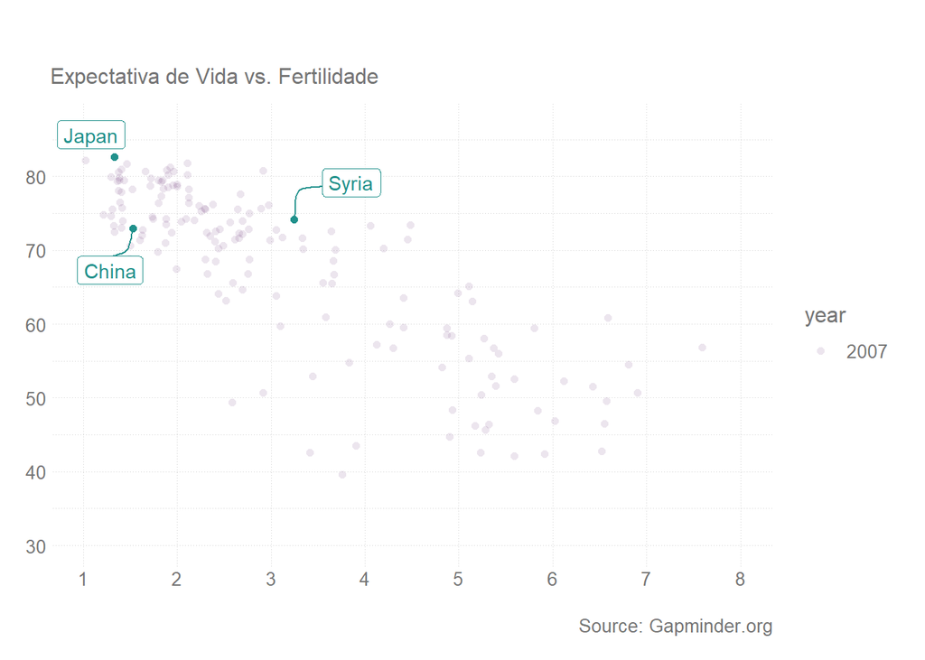

```r
temp <- gapminder_full %>%
  filter(continent != "FSU") %>%
  filter(year %in% c("2007")) %>%
  #filter(continent == "Europa") %>%
  mutate(year = as_factor(year))

(p <- temp %>%
  ggplot(aes(x = fertility, y = life_exp, color = year, label = country))  +
    geom_point(shape=16, size  = 2, stroke = 0, alpha = 0.1) +
    # geom_point(data = . %>% filter(life_exp == max(life_exp)),
    #            color = "#21918c") +
    # ggrepel::geom_label_repel(data = . %>%
    #                             filter(life_exp >70, fertility >3, fertility <4),
    #                   color = "#21918c",
    #                   max.overlaps = 50,
    #                   nudge_x = -.3, nudge_y = 3,
    #                   segment.curvature = 0.9) +
    geom_point(data = . %>% filter(country == "Syria"),
               shape=16, size  = 2, stroke = 0, color = "#21918c") +
    ggrepel::geom_label_repel(data = . %>% filter(country == "Syria"),
                          color = "#21918c",
                          max.overlaps = 50,
                          nudge_x = .3, nudge_y = 3,
                          box.padding = 1,
                          segment.curvature = 0.9) +
    geom_point(data = . %>% filter(country == "Japan"),
               shape=16, size  = 2, stroke = 0, color = "#21918c") +
    ggrepel::geom_label_repel(data = . %>% filter(country == "Japan"),
                          color = "#21918c",
                          max.overlaps = 50,
                          nudge_x = -.3, nudge_y = 3,
                          segment.curvature = 0.5) +
    geom_point(data = . %>% filter(country == "China"),
               shape=16, size  = 2, stroke = 0, color = "#21918c") +
    ggrepel::geom_label_repel(data = . %>% filter(country == "China"),
                              color = "#21918c",
                              max.overlaps = 50,
                              nudge_x = -.1, nudge_y = -1.5,
                              box.padding = 1,
                              segment.curvature = 0.5) +
    scale_color_manual(values = c("#440154")) +
    labs(title = "",
         subtitle = "Expectativa de Vida vs. Fertilidade",
         caption = "Source: Gapminder.org",
         x = NULL,
         y = NULL,
         fill = NULL) +
    theme_nath() +
    scale_x_continuous(limits = c(1, 8), minor_breaks = seq(1, 8, 1), n.breaks = 8) +
    scale_y_continuous(limits = c(30, 87)) +
    theme(#panel.grid.major.x = element_blank(),
          panel.grid.major = element_line(linetype = "dotted", colour = "lightgrey", size = 0.2),
          panel.grid.minor = element_line(linetype = "dotted", colour = "lightgrey", size = 0.2),
         legend.position = "right"))
```

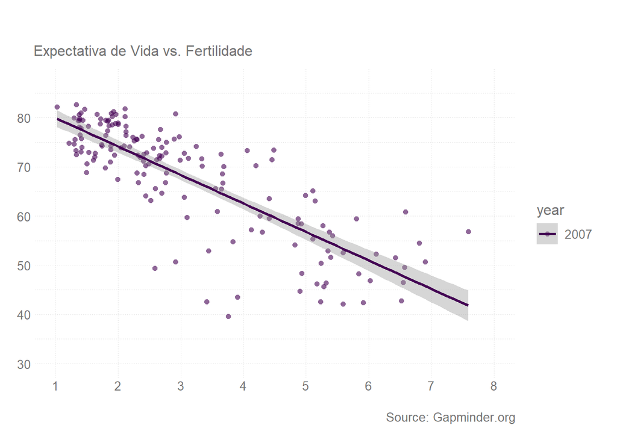

```r
( p <- gapminder_full %>%
  filter(continent != "FSU") %>%
  filter(year %in% c("2007")) %>%
  #filter(continent == "Europa") %>%
  mutate(year = as_factor(year)) %>%
  ggplot(aes(x = fertility, y = life_exp, color = year, label = country))  +
    #scale_y_continuous(labels = scales::comma, expand = c(0, 0)) +
    geom_point(shape=16, size  = 2, stroke = 0, alpha = 0.6) +
    geom_smooth(method = "lm") +
    viridis::scale_color_viridis(discrete = T, direction = 1) +
    labs(title = "",
         #subtitle = "Expectativa de Vida vs. Fertilidade, comparação por período",
         subtitle = "Expectativa de Vida vs. Fertilidade",
         caption = "Source: Gapminder.org",
         x = NULL,
         y = NULL,
         fill = NULL) +
    theme_nath() +
    scale_x_continuous(limits = c(1, 8), minor_breaks = seq(1, 8, 1), n.breaks = 8) +
    scale_y_continuous(limits = c(30, 87)) +
    theme(#panel.grid.major.x = element_blank(),
          panel.grid.major = element_line(linetype = "dotted", colour = "lightgrey", size = 0.2),
          panel.grid.minor = element_line(linetype = "dotted", colour = "lightgrey", size = 0.2),
         legend.position = "right"))
```

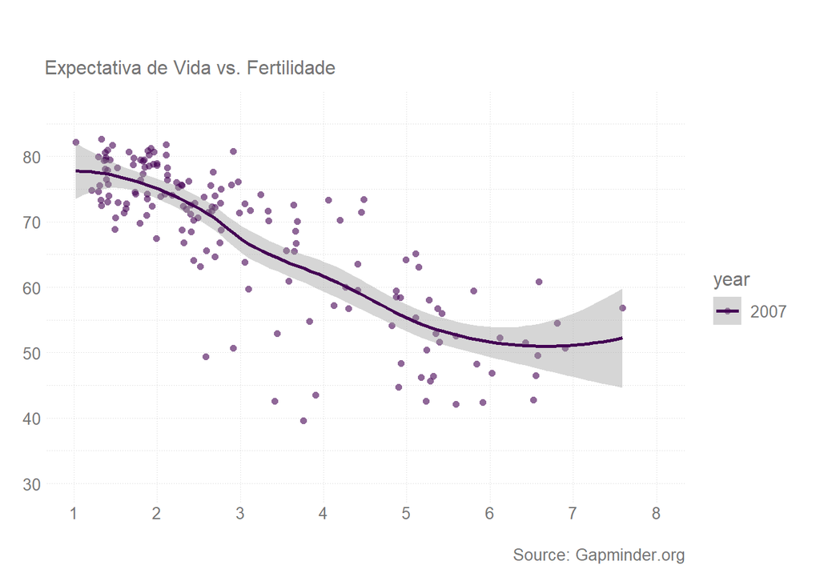

```r
( p <- gapminder_full %>%
  filter(continent != "FSU") %>%
  filter(year %in% c("2007")) %>%
  #filter(continent == "Europa") %>%
  mutate(year = as_factor(year)) %>%
  ggplot(aes(x = fertility, y = life_exp, color = year, label = country))  +
    #scale_y_continuous(labels = scales::comma, expand = c(0, 0)) +
    geom_point(shape=16, size  = 2, stroke = 0, alpha = 0.6) +
    geom_smooth() +
    viridis::scale_color_viridis(discrete = T, direction = 1) +
    #scale_color_manual(values = c('#9ccb86','#cf597e', '#009392','#eeb479' )) +
    labs(title = "",
         #subtitle = "Expectativa de Vida vs. Fertilidade, comparação por período",
         subtitle = "Expectativa de Vida vs. Fertilidade",
         caption = "Source: Gapminder.org",
         x = NULL,
         y = NULL,
         fill = NULL) +
    theme_nath() +
    scale_x_continuous(limits = c(1, 8), minor_breaks = seq(1, 8, 1), n.breaks = 8) +
    scale_y_continuous(limits = c(30, 87)) +
    theme(#panel.grid.major.x = element_blank(),
          panel.grid.major = element_line(linetype = "dotted", colour = "lightgrey", size = 0.2),
          panel.grid.minor = element_line(linetype = "dotted", colour = "lightgrey", size = 0.2),
         legend.position = "right"))
```

### overplotting

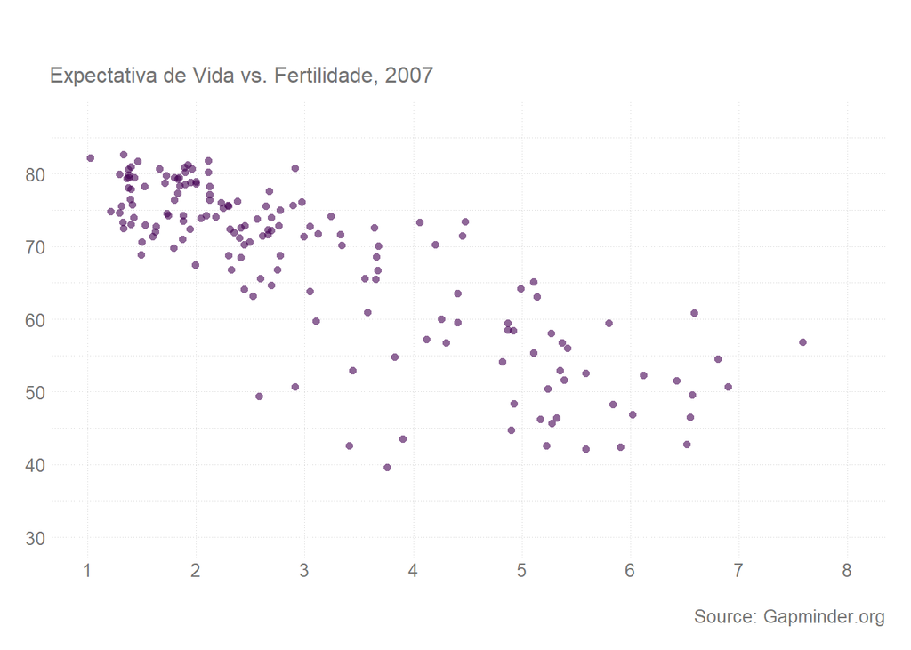

```r
( p <- gapminder_full %>%
  filter(continent != "FSU") %>%
  filter(year %in% c("2007")) %>%
  #filter(continent == "Europa") %>%
  mutate(year = as_factor(year)) %>%
  ggplot(aes(x = fertility, y = life_exp, label = country))  +
    #scale_y_continuous(labels = scales::comma, expand = c(0, 0)) +
    geom_point(shape=16, size  = 2, stroke = 0, alpha = 0.6, color = "#440154") +
    #viridis::scale_color_viridis(discrete = T, direction = 1) +
    labs(title = "",
         #subtitle = "Expectativa de Vida vs. Fertilidade, comparação por período",
         subtitle = "Expectativa de Vida vs. Fertilidade, 2007",
         caption = "Source: Gapminder.org",
         x = NULL,
         y = NULL,
         fill = NULL) +
    theme_nath() +
    scale_x_continuous(limits = c(1, 8), minor_breaks = seq(1, 8, 1), n.breaks = 8) +
    scale_y_continuous(limits = c(30, 87)) +
    theme(#panel.grid.major.x = element_blank(),
          panel.grid.major = element_line(linetype = "dotted", colour = "lightgrey", size = 0.2),
          panel.grid.minor = element_line(linetype = "dotted", colour = "lightgrey", size = 0.2),
         legend.position = "right"))
```

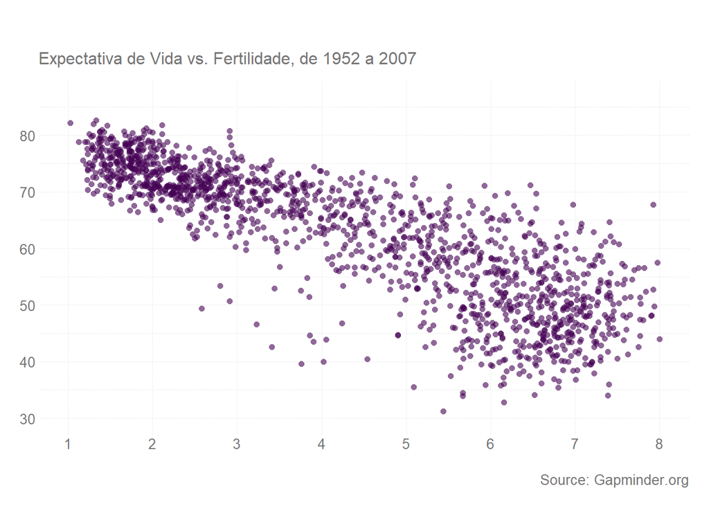

```r
( p <- gapminder_full %>%
  filter(continent != "FSU") %>%
  #filter(year %in% c("2007")) %>%
  #filter(continent == "Europa") %>%
  mutate(year = as_factor(year)) %>%
  ggplot(aes(x = fertility, y = life_exp, label = country))  +
    #scale_y_continuous(labels = scales::comma, expand = c(0, 0)) +
    geom_point(shape=16, size  = 2, stroke = 0, alpha = 0.6, color = "#440154") +
    #viridis::scale_color_viridis(discrete = T, direction = 1) +
    labs(title = "",
         #subtitle = "Expectativa de Vida vs. Fertilidade, comparação por período",
         subtitle = "Expectativa de Vida vs. Fertilidade, de 1952 a 2007",
         caption = "Source: Gapminder.org",
         x = NULL,
         y = NULL,
         fill = NULL) +
    theme_nath() +
    scale_x_continuous(limits = c(1, 8), minor_breaks = seq(1, 8, 1), n.breaks = 8) +
    scale_y_continuous(limits = c(30, 87)) +
    theme(#panel.grid.major.x = element_blank(),
          panel.grid.major = element_line(linetype = "dotted", colour = "lightgrey", size = 0.2),
          panel.grid.minor = element_line(linetype = "dotted", colour = "lightgrey", size = 0.2),
         legend.position = "right"))
```

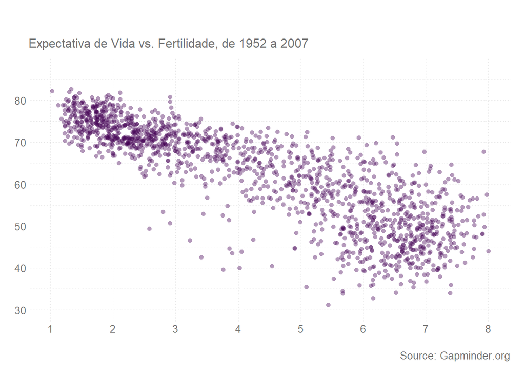

```r
( p <- gapminder_full %>%
  filter(continent != "FSU") %>%
  #filter(year %in% c("2007")) %>%
  #filter(continent == "Europa") %>%
  mutate(year = as_factor(year)) %>%
  ggplot(aes(x = fertility, y = life_exp, label = country))  +
    #scale_y_continuous(labels = scales::comma, expand = c(0, 0)) +
    geom_point(shape=16, size  = 2, stroke = 0, alpha = 0.4, color = "#440154") +
    #viridis::scale_color_viridis(discrete = T, direction = 1) +
    labs(title = "",
         #subtitle = "Expectativa de Vida vs. Fertilidade, comparação por período",
         subtitle = "Expectativa de Vida vs. Fertilidade, de 1952 a 2007",
         caption = "Source: Gapminder.org",
         x = NULL,
         y = NULL,
         fill = NULL) +
    theme_nath() +
    scale_x_continuous(limits = c(1, 8), minor_breaks = seq(1, 8, 1), n.breaks = 8) +
    scale_y_continuous(limits = c(30, 87)) +
    theme(#panel.grid.major.x = element_blank(),
          panel.grid.major = element_line(linetype = "dotted", colour = "lightgrey", size = 0.2),
          panel.grid.minor = element_line(linetype = "dotted", colour = "lightgrey", size = 0.2),
         legend.position = "right"))
```

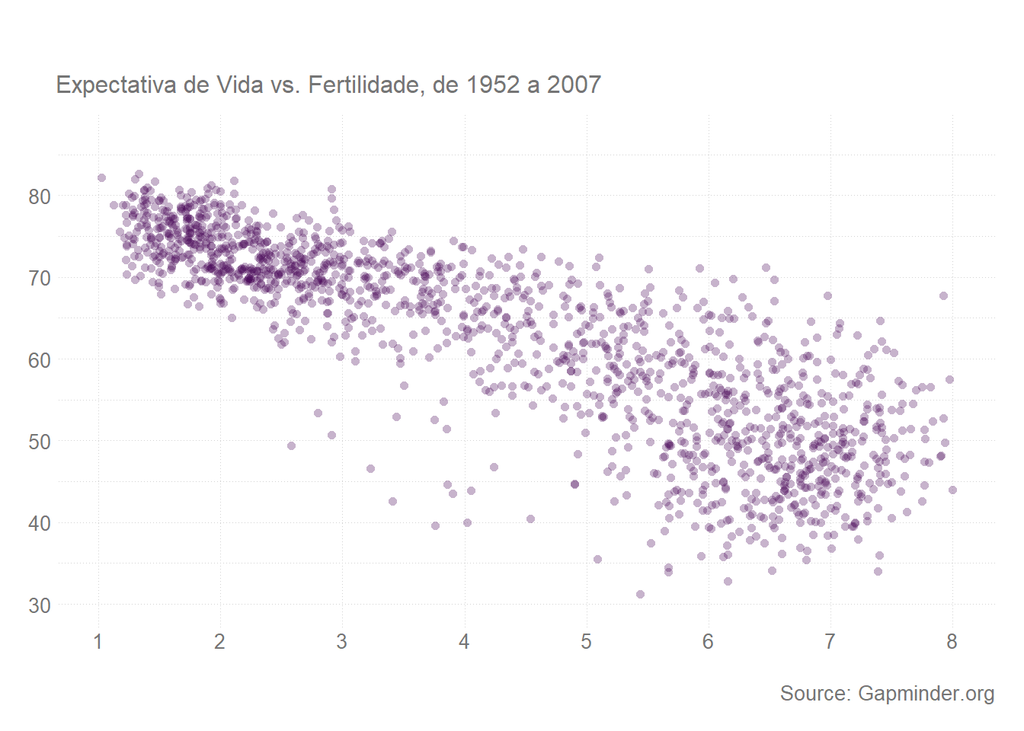

```r
( p <- gapminder_full %>%
  filter(continent != "FSU") %>%
  #filter(year %in% c("2007")) %>%
  #filter(continent == "Europa") %>%
  mutate(year = as_factor(year)) %>%
  ggplot(aes(x = fertility, y = life_exp, label = country))  +
    #scale_y_continuous(labels = scales::comma, expand = c(0, 0)) +
    geom_point(shape=16, size  = 2, stroke = 0, alpha = 0.3, color = "#440154") +
    #viridis::scale_color_viridis(discrete = T, direction = 1) +
    labs(title = "",
         #subtitle = "Expectativa de Vida vs. Fertilidade, comparação por período",
         subtitle = "Expectativa de Vida vs. Fertilidade, de 1952 a 2007",
         caption = "Source: Gapminder.org",
         x = NULL,
         y = NULL,
         fill = NULL) +
    theme_nath() +
    scale_x_continuous(limits = c(1, 8), minor_breaks = seq(1, 8, 1), n.breaks = 8) +
    scale_y_continuous(limits = c(30, 87)) +
    theme(#panel.grid.major.x = element_blank(),
          panel.grid.major = element_line(linetype = "dotted", colour = "lightgrey", size = 0.2),
          panel.grid.minor = element_line(linetype = "dotted", colour = "lightgrey", size = 0.2),
         legend.position = "right"))
```

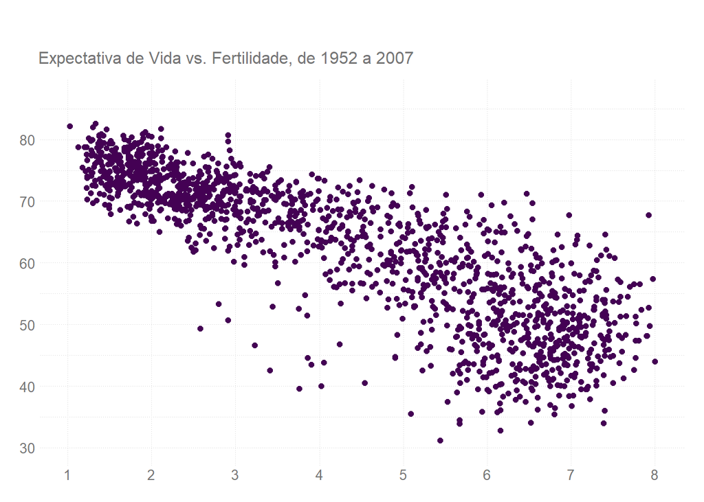

```r
( p <- gapminder_full %>%
  filter(continent != "FSU") %>%
  #filter(year %in% c("2007")) %>%
  #filter(continent == "Europa") %>%
  mutate(year = as_factor(year)) %>%
  ggplot(aes(x = fertility, y = life_exp, label = country))  +
    #scale_y_continuous(labels = scales::comma, expand = c(0, 0)) +
    geom_point(shape=16, size  = 2, stroke = 0, alpha = 1, color = "#440154") +
    #viridis::scale_color_viridis(discrete = T, direction = 1) +
    labs(title = "",
         #subtitle = "Expectativa de Vida vs. Fertilidade, comparação por período",
         subtitle = "Expectativa de Vida vs. Fertilidade, de 1952 a 2007",
        # caption = "Source: Gapminder.org",
         x = NULL,
         y = NULL,
         fill = NULL) +
    theme_nath() +
    scale_x_continuous(limits = c(1, 8), minor_breaks = seq(1, 8, 1), n.breaks = 8) +
    scale_y_continuous(limits = c(30, 87)) +
    theme(#panel.grid.major.x = element_blank(),
          panel.grid.major = element_line(linetype = "dotted", colour = "lightgrey", size = 0.2),
          panel.grid.minor = element_line(linetype = "dotted", colour = "lightgrey", size = 0.2),
         legend.position = "right"))
```

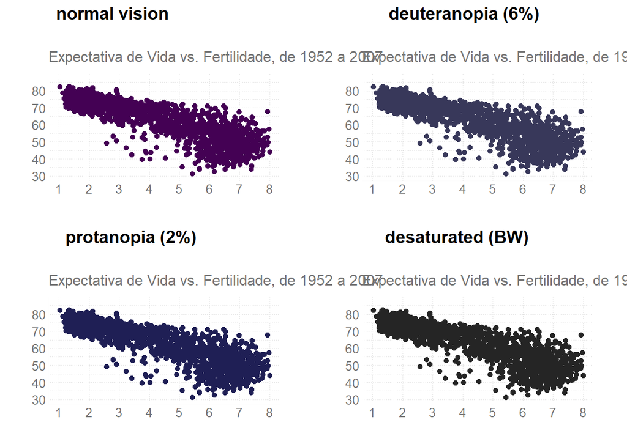

```r
colorBlindness::cvdPlot(p)
```

## continents

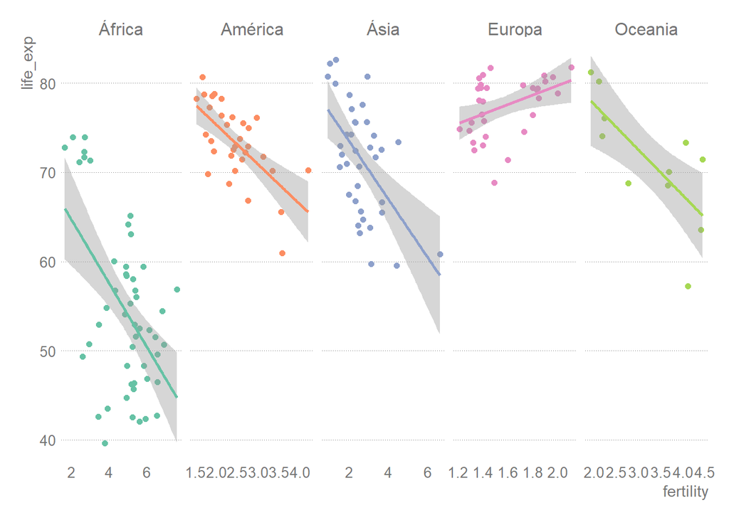

```r
( p <- gapminder_full %>%
  filter(continent != "FSU") %>%
  #filter(year %in% c(1952, 1957, 1962, 1967, 1972, 1977, 1982, 1987, 1992, 1997, 2002)) %>%
  filter(year == "2007") %>%
  #filter(continent == "Oceania") %>%
  group_by(year, country, continent) %>%
  summarise(
    life_exp = mean(life_exp, na.rm=T),
    fertility = mean(fertility, na.rm=T)
  ) %>%
  ungroup() %>%
  mutate(year = as_factor(year)) %>%
  ggplot(aes(x = fertility, y = life_exp, color = continent))  +
    #ggplot(aes(x = continent, y = n, group = year, fill = year)) +
    #geom_col(position = "dodge", colour = "white", size = 0.2, alpha = 0.8) +
    #scale_y_continuous(labels = scales::comma, expand = c(0, 0)) +
    #geom_text(aes(label = country), vjust = "inward") +
    geom_point() +
    geom_smooth(method = "glm") +
    facet_grid(. ~ continent, scales = "free_x") +
    scale_color_brewer(palette = "Set2") +
    # labs(title = "",
    #      subtitle = "Contagem de Países por Continente, de 1952 a 2002",
    #      caption = "Source: Gapminder.org",
    #      x = NULL,
    #      y = NULL,
    #      fill = NULL) +
    theme_nath() +
    theme(panel.grid.major.x = element_blank(),
         legend.position = "none"))
```

```r
# plotly::ggplotly(p)
```

## gdp_percap x life_exp

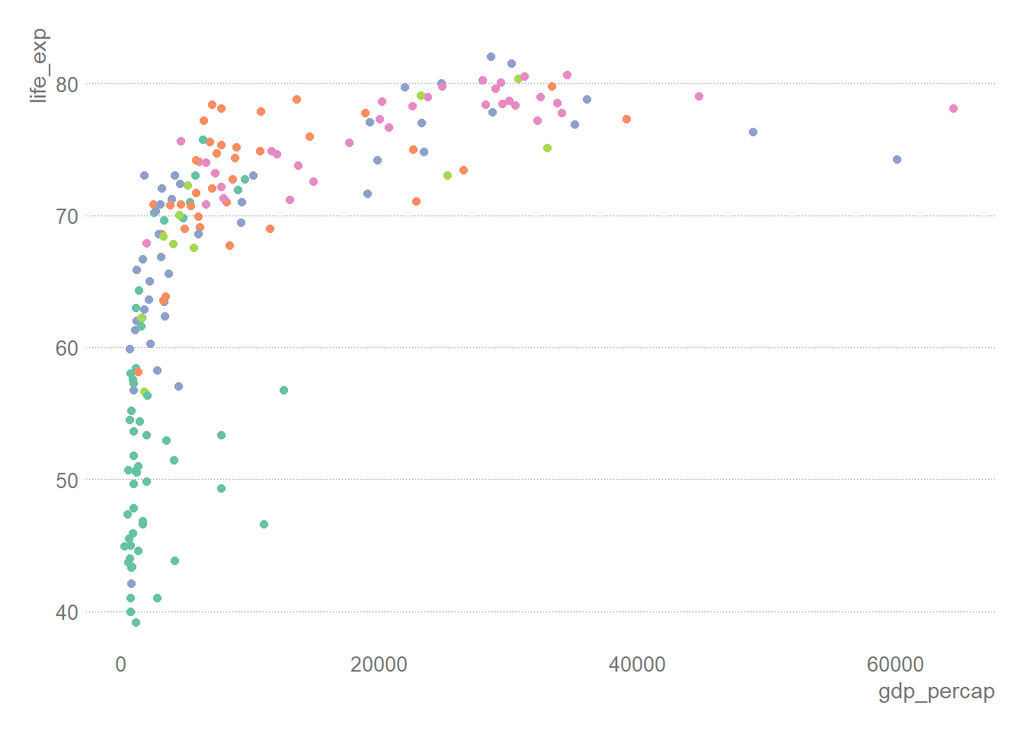

```r
( p <- gapminder_full %>%
  filter(continent != "FSU") %>%
  filter(year %in% c(1952, 1957, 1962, 1967, 1972, 1977, 1982, 1987, 1992, 1997, 2002)) %>%
  filter(year == "2002") %>%
  #filter(continent == "Oceania") %>%
  # group_by(year, country, continent) %>%
  # summarise(
  #   life_exp = mean(life_exp, na.rm=T),
  #   fertility = mean(fertility, na.rm=T)
  # ) %>%
  # ungroup() %>%
  mutate(year = as_factor(year)) %>%
  ggplot(aes(x = gdp_percap, y = life_exp, color = continent))  +
    #ggplot(aes(x = continent, y = n, group = year, fill = year)) +
    #geom_col(position = "dodge", colour = "white", size = 0.2, alpha = 0.8) +
    #scale_y_continuous(labels = scales::comma, expand = c(0, 0)) +
    #stat_summary(geom="point", fun.data = ~mean(.x,na.rm=T)) +
    #geom_text(aes(label = country), vjust = "inward") +
    geom_point() +
    #geom_smooth(method = "glm") +
    scale_color_brewer(palette = "Set2") +
    # labs(title = "",
    #      subtitle = "Contagem de Países por Continente, de 1952 a 2002",
    #      caption = "Source: Gapminder.org",
    #      x = NULL,
    #      y = NULL,
    #      fill = NULL) +
    #scale_x_log10(labels = scales::dollar) +
    theme_nath() +
    theme(panel.grid.major.x = element_blank(),
         legend.position = "none"))
```

```r
# plotly::ggplotly(p)
```

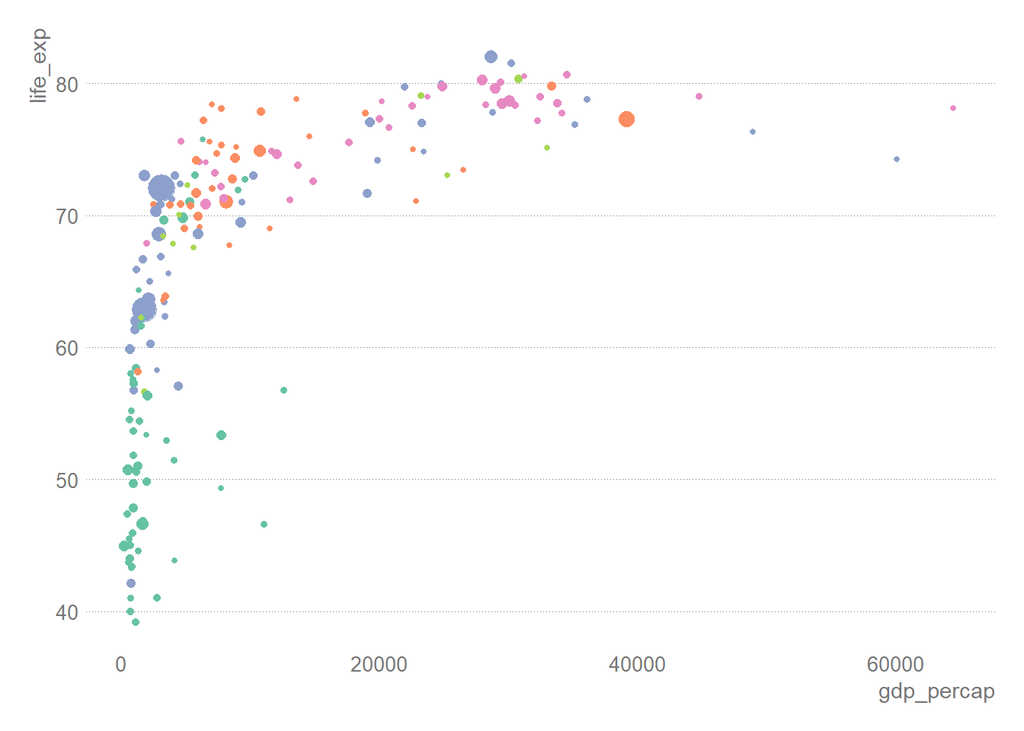

```r
( p <- gapminder_full %>%
  filter(continent != "FSU") %>%
  filter(year %in% c(1952, 1957, 1962, 1967, 1972, 1977, 1982, 1987, 1992, 1997, 2002)) %>%
  filter(year == "2002") %>%
  #filter(continent == "Oceania") %>%
  # group_by(year, country, continent) %>%
  # summarise(
  #   life_exp = mean(life_exp, na.rm=T),
  #   fertility = mean(fertility, na.rm=T)
  # ) %>%
  # ungroup() %>%
  mutate(year = as_factor(year)) %>%
  ggplot(aes(x = gdp_percap, y = life_exp, color = continent))  +
    #ggplot(aes(x = continent, y = n, group = year, fill = year)) +
    #geom_col(position = "dodge", colour = "white", size = 0.2, alpha = 0.8) +
    #scale_y_continuous(labels = scales::comma, expand = c(0, 0)) +
    #stat_summary(geom="point", fun.data = ~mean(.x,na.rm=T)) +
    #geom_text(aes(label = country), vjust = "inward") +
    geom_point(aes(size = pop)) +
    #geom_smooth(method = "glm") +
    scale_color_brewer(palette = "Set2") +
    # labs(title = "",
    #      subtitle = "Contagem de Países por Continente, de 1952 a 2002",
    #      caption = "Source: Gapminder.org",
    #      x = NULL,
    #      y = NULL,
    #      fill = NULL) +
    #scale_x_log10(labels = scales::dollar) +
    theme_nath() +
    theme(panel.grid.major.x = element_blank(),
         legend.position = "none"))
```

```r
# plotly::ggplotly(p)
```

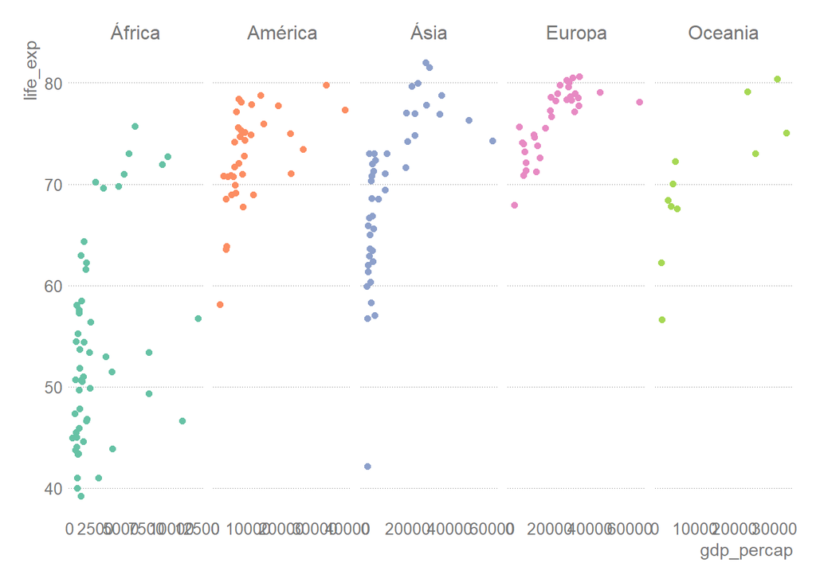

```r
( p <- gapminder_full %>%
  filter(continent != "FSU") %>%
  filter(year %in% c(1952, 1957, 1962, 1967, 1972, 1977, 1982, 1987, 1992, 1997, 2002)) %>%
  filter(year == "2002") %>%
  #filter(continent == "Oceania") %>%
  # group_by(year, country, continent) %>%
  # summarise(
  #   life_exp = mean(life_exp, na.rm=T),
  #   fertility = mean(fertility, na.rm=T)
  # ) %>%
  # ungroup() %>%
  mutate(year = as_factor(year)) %>%
  ggplot(aes(x = gdp_percap, y = life_exp, color = continent))  +
    #ggplot(aes(x = continent, y = n, group = year, fill = year)) +
    #geom_col(position = "dodge", colour = "white", size = 0.2, alpha = 0.8) +
    #scale_y_continuous(labels = scales::comma, expand = c(0, 0)) +
    #stat_summary(geom="point", fun.data = ~mean(.x,na.rm=T)) +
    #geom_text(aes(label = country), vjust = "inward") +
    geom_point() +
    #geom_smooth(method = "glm") +
    facet_grid(. ~ continent, scales = "free_x") +
    scale_color_brewer(palette = "Set2") +
    # labs(title = "",
    #      subtitle = "Contagem de Países por Continente, de 1952 a 2002",
    #      caption = "Source: Gapminder.org",
    #      x = NULL,
    #      y = NULL,
    #      fill = NULL) +
    #scale_x_log10(labels = scales::dollar) +
    theme_nath() +
    theme(panel.grid.major.x = element_blank(),
         legend.position = "none"))
```

```r
# plotly::ggplotly(p)
```

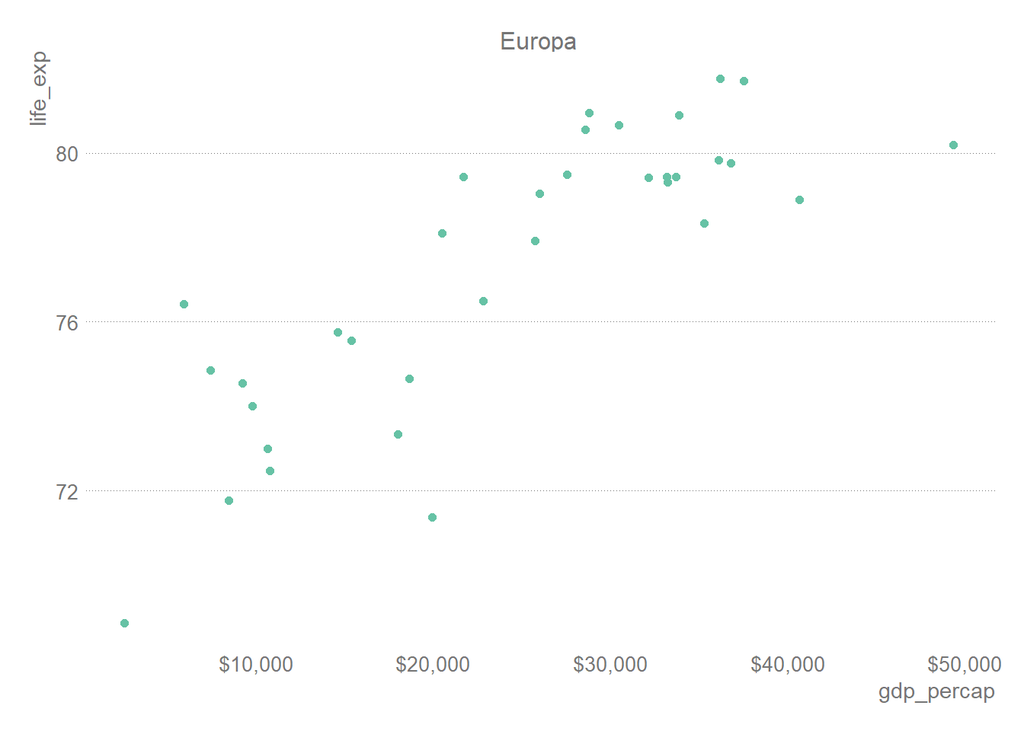

```r
( p <- gapminder_full %>%
  filter(continent != "FSU") %>%
  #filter(year %in% c(1952, 1957, 1962, 1967, 1972, 1977, 1982, 1987, 1992, 1997, 2002)) %>%
  filter(year == "2007") %>%
  filter(continent == "Europa") %>%
  # group_by(year, country, continent) %>%
  # summarise(
  #   life_exp = mean(life_exp, na.rm=T),
  #   fertility = mean(fertility, na.rm=T)
  # ) %>%
  # ungroup() %>%
  mutate(year = as_factor(year)) %>%
  ggplot(aes(x = gdp_percap, y = life_exp, color = continent))  +
    #ggplot(aes(x = continent, y = n, group = year, fill = year)) +
    #geom_col(position = "dodge", colour = "white", size = 0.2, alpha = 0.8) +
    #scale_y_continuous(labels = scales::comma, expand = c(0, 0)) +
    #stat_summary(geom="point", fun.data = ~mean(.x,na.rm=T)) +
    #geom_text(aes(label = country), vjust = "inward") +
    geom_point() +
    #geom_smooth(method = "glm") +
    facet_grid(. ~ continent, scales = "free_x") +
    scale_color_brewer(palette = "Set2") +
    # labs(title = "",
    #      subtitle = "Contagem de Países por Continente, de 1952 a 2002",
    #      caption = "Source: Gapminder.org",
    #      x = NULL,
    #      y = NULL,
    #      fill = NULL) +
    scale_x_continuous(labels = scales::dollar) +
    theme_nath() +
    theme(panel.grid.major.x = element_blank(),
         legend.position = "none"))
```

```r
# plotly::ggplotly(p)
```

# Evolução

## fertility

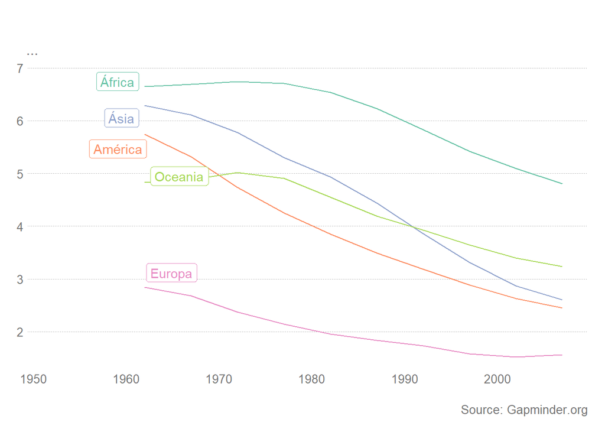

```r
gapminder_full %>%
  filter(continent != "FSU") %>%
  #filter(year == "2007") %>%
  group_by(continent, year) %>%
  summarise(
    NA_fertility = sum(is.na(fertility)),
    mean_fertility = mean(fertility, na.rm = T),
    ) %>%
  ggplot(aes(x = year, y = mean_fertility, color = continent))  +
    #geom_point(color = "gray") +
    #geom_line(aes(group = country), color = "gray") +
    # geom_point(alpha = 0.3) +
    geom_line() +
    ggrepel::geom_label_repel(data = . %>% filter(year == 1962), aes(label = continent)) +
    scale_colour_brewer(palette = "Set2") +
    guides(fill = guide_legend(reverse = F)) +
    labs(title = "",
       subtitle = "...",
       caption = "Source: Gapminder.org",
       x = NULL,
       y = NULL,
       fill = NULL) +
    theme_nath() +
    theme(panel.grid.major.x = element_blank(),
          legend.position = "none")
```